# Graphing Options - GISAID and Data Portal Uploads

Erin Gill

28/03/2022

## Considerations

In order to incorporate information on each province’s uploads to **GISIAD** and the **VirusSeq Data Portal**, we need to make a few decisions about:

- *how to present the data*
- *whether we want to include historical data or just the most recent data* (I have historical data going back to June 2021 for the Data Portal and September 2020 for GISAID)

In order to make these decisions, I’ve made some sample plots with a test dataset.

### Let’s take a look at the dataset

Number of sequences uploaded to GISAID and the Data Portal by country

| country | GISAID | Portal |
| --- | --- | --- |
| Australia | 10 | 15 |
| Belgium | 10 | 12 |
| Canada | 39 | 32 |
| Denmark | 8 | 8 |
| France | 19 | 21 |
| Germany | 13 | 14 |
| India | 36 | 42 |
| Italy | 14 | 14 |
| Japan | 41 | 53 |
| Netherlands | 18 | 18 |
| Spain | 18 | 18 |
| Sweden | 21 | 18 |
| Switzerland | 13 | 14 |
| UK | 10 | 8 |
| USA | 19 | 23 |

### First, let’s look at a bar plot

Sequences uploaded to the two repositories are overlaid for each country, and the alpha parameter is decreased so that you can easily see when a country has uploaded more to one repository than another

In the following plots, imagine that countries are **provinces**

[figure not shown]

### Here’s a second barplot option where sequences uploaded to each repository are plotted side by side for each country

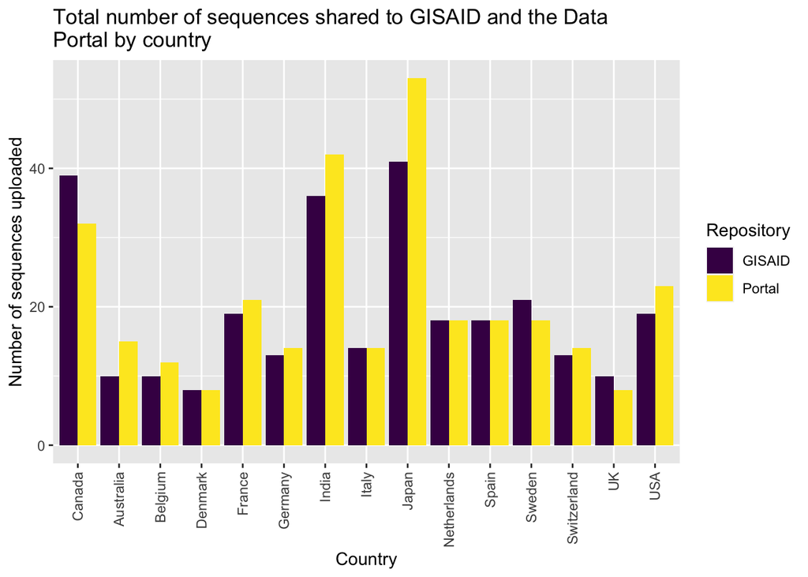

## What if we want to look at upload progress over time?

Here’s the first few rows of a second dataset that contains multiple time points

Number of sequences uploaded to GISAID and the Data Portal over time by country

| country | repository | number | date |
| --- | --- | --- | --- |
| Australia | GISAID | 10 | 2021-08-01 |
| Belgium | GISAID | 10 | 2021-08-01 |
| Canada | GISAID | 39 | 2021-08-01 |
| Denmark | GISAID | 8 | 2021-08-01 |
| France | GISAID | 19 | 2021-08-01 |
| Germany | GISAID | 13 | 2021-08-01 |
| India | GISAID | 36 | 2021-08-01 |
| Italy | GISAID | 14 | 2021-08-01 |
| Japan | GISAID | 41 | 2021-08-01 |
| Netherlands | GISAID | 18 | 2021-08-01 |

### Here each country is plotted separately and you can see if the “rate of upload” has been increasing or decreasing to both repositories

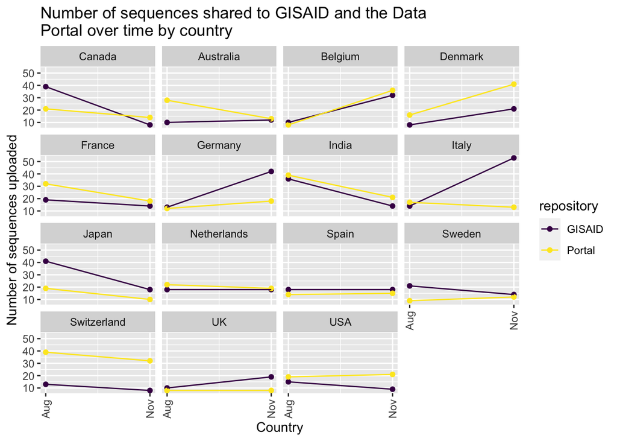

### The same plot as above, but a bar plot instead of a line plot

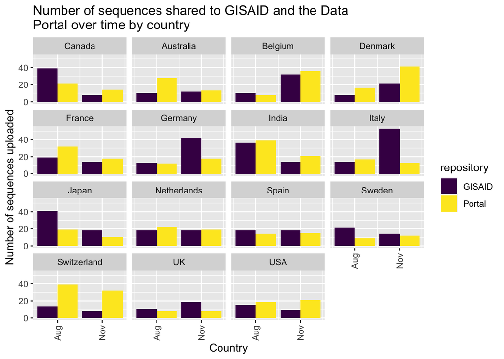